# Pec2 Datos Omicos Cristina Lendinez

Cristina Lendinez

```r
require(knitr)
```

```r
# include this code chunk as-is to set options
opts_chunk$set(comment = NA, prompt = TRUE, tidy = FALSE,
               fig.width = 7, fig.height = 7,echo = TRUE,
               message = FALSE, warning = FALSE, cache=TRUE)
```

```r
> library(knitr)
> library(kableExtra)
> library(printr)
> library(tinytex)
> library(rstudioapi)
```

# Abstract

Al filo del Año Nuevo 2020, se identificó en la ciudad china de Wuhan la COVID-19, Aunque único en su transmisión y virulencia, el COVID-19 es similar a las enfermedades zoonóticas, incluidas otras variantes del SARS (p. ej., el SARS-CoV) y el MERS, al presentar síntomas graves similares a los de la gripe y dificultad respiratoria aguda. Incluso a nivel molecular, se han identificado muchos paralelismos entre el SARS y la COVID-19, tanto que el virus de la COVID-19 se ha denominado SARS-CoV-2. Es importante destacar que la identificación de similitudes en la forma en que el SARS-CoV y el SARS-CoV-2 acceden al host, se replican y y desencadenar condiciones patológicas que amenazan la vida han revelado oportunidades para reutilizar medicamentos que demostraron ser efectivos contra el SARS.

# OBJETIVOS

Los cambios de expresión génica pueden ser dados por la presión de la evolución natural sobre la regulación de los genes. El objetivo principal del siguiente estudio se centra en identificar diferencias de expresión génica en un análisis del virus COVID-19, el experimento se divide en : *Infectados(COVID)*, *Sanos(SANOS)*. En este estudio se pretende usar técnicas de secuenciación de RNA para identificar dichos genes y determinar su significación biológica.

# MATERIALES Y MÉTODOS

## Software

El presente análisis se realiza con el software estadístico R (https://cran.r-project.org/index.html), utilizándose la última versión disponible 4.1.2. La interacción con R se realiza a partir de la interfaz *RStudio* (https://www.rstudio.com/).

Algunas de las librerias indicadas forman parte del proyecto Bioconductor (https://www.bioconductor.org/), a partir del cual se disponen de gran varidad de librerías dedicadas al análisis de microarrays y datos ómicos. la version usada de Bioconductor es la versión 3.12 (BiocManager 1.30.10).

## Datos

- *Infectados de Covid-19(COVID): 17 muestras*
- *Controles Sanos (Sanos): 17 muestras*

```r
> # ============================================
> # Configuración del directorio de trabajo
> # ============================================
>
> #Limpieza de mente
> rm(list = ls())
>
> # Creo los directorios
> setwd(".")
> dir.create("data")
> dir.create("results")
```

```r
> # ============================================
> # Función para la selección de muestras
> # ============================================
>
> selectSamples<- function (myID) {
+   set.seed(myID)
+   selected <- c(sample(1:17, 10), sample(18:35,10))
+   selected <- sort(selected)
+ }
```

```r
> # ============================================
> # Cargo el archivo targets creado y selecionamos las muestras aleatoriamente
> # ============================================
>
> mySelected <- selectSamples(98127)
> targets <- read.csv2(file="./data/targets.csv", header = TRUE, sep = ";")
> sampleTable <- targets[mySelected,]
>
> # Nueva variable con nueva definición de nombres de las muestras.Permite comparar el nombre de las muestras entre filas y columnas.
> sampleTable$NewName <- gsub("-", ".", sampleTable$SampleName, fixed = TRUE)
> sampleinfo<-sampleTable
> require(Biobase)
> sampleinfo<-AnnotatedDataFrame(targets)
> show(pData(sampleinfo))
```

[output not shown]

```r
> # ============================================
> # Carga Cargamos el archivo Count y selecionamos las columnas
> # ============================================
> library(dplyr)
> counts <- read.csv2(file = "data/RawCounts.csv", sep = ",", row.names = 1)
>
> # Se seleccionan las columnas en base a las muestras seleccionadas de targets
> countdata <- select(counts, one_of(sampleTable$NewName))
```

## Eliminación de los tránscritos con demasiados ceros.

```r
> countdata<-counts[rowSums(counts ==0)<=3,]
```

# Preprocesado de los datos

## Filtraje de genes poco expresados

Los genes con recuentos muy bajos en todas las librerías proporcionan poca evidencia de expresión diferencial e interfieren con algunas de las aproximaciones estadísticas que se utilizarán más adelante. Además penalizan los ajustes por comparaciones múltiples para estimar las tasas de falsos positivos, lo que resta potencia para detectar genes expresados diferencialmente. Por este motivo, se aconseja filtrar estos genes antes de continuar los análisis.

Antes de filtrar, sin embargo, expresaremos los contajes en “CPMs” es decir “counts per million” con el fin de evitar que se atribuyan valores demasiado bajos debido a tamaños distintos de las librerías.

Es decir, en primer lugar se estandarizan los contajes basándonos en el tamaño de la librería y a continuación se realizará el filtraje.

Para ello se normalizaran los contajes brutos para las diferentes profundidades de secuenciación (tamaños de librería) para cada muestra y se compararan con los valores de recuento por millón (CPM) utilizando la función cpm() del paquete edgeR.

## Convertir recuentos en objeto DGEList

Creo un objeto DGEList. Este es un objeto utilizado por edgeR aquí al almacenaremos datos de recuento. El algoritmo dispone de varias ranuras para almacenar varios parámetros sobre los datos.

```r
> y <- DGEList(countdata)
> names(y)
```

```
[1] "counts"  "samples"
```

```r
> y$samples
```

|  | group | lib.size | norm.factors |
| --- | --- | --- | --- |
| COV145 | 1 | 15016281 | 1 |
| COV147 | 1 | 13910282 | 1 |
| COV149 | 1 | 13481021 | 1 |
| COV150 | 1 | 18827894 | 1 |
| COV151 | 1 | 13631775 | 1 |
| COV152 | 1 | 13243269 | 1 |
| COV153 | 1 | 12945595 | 1 |
| COV154 | 1 | 14267919 | 1 |
| COV155 | 1 | 17121691 | 1 |
| COV156 | 1 | 15587247 | 1 |
| COV157 | 1 | 16980283 | 1 |
| COV175 | 1 | 13331343 | 1 |
| COV176 | 1 | 13643694 | 1 |
| COV177 | 1 | 16054854 | 1 |
| COV178 | 1 | 17328282 | 1 |
| COV179 | 1 | 13617368 | 1 |
| COV180 | 1 | 13684884 | 1 |
| HEA061 | 1 | 16971921 | 1 |
| HEA062 | 1 | 17341153 | 1 |
| HEA063 | 1 | 15554734 | 1 |
| HEA064 | 1 | 16136531 | 1 |
| HEA065 | 1 | 19401409 | 1 |
| HEA066 | 1 | 18235722 | 1 |
| HEA067 | 1 | 16377605 | 1 |
| HEA068 | 1 | 14864451 | 1 |
| HEA069 | 1 | 14920545 | 1 |
| HEA070 | 1 | 20425308 | 1 |
| HEA071 | 1 | 17804131 | 1 |
| HEA181 | 1 | 14938779 | 1 |
| HEA182 | 1 | 14256835 | 1 |
| HEA183 | 1 | 18268429 | 1 |
| HEA184 | 1 | 17127622 | 1 |
| HEA185 | 1 | 16448075 | 1 |
| HEA186 | 1 | 16816728 | 1 |

```r
> colSums(countdata)
```

```
  COV145   COV147   COV149   COV150   COV151   COV152   COV153   COV154
15016281 13910282 13481021 18827894 13631775 13243269 12945595 14267919
  COV155   COV156   COV157   COV175   COV176   COV177   COV178   COV179
17121691 15587247 16980283 13331343 13643694 16054854 17328282 13617368
  COV180   HEA061   HEA062   HEA063   HEA064   HEA065   HEA066   HEA067
13684884 16971921 17341153 15554734 16136531 19401409 18235722 16377605
  HEA068   HEA069   HEA070   HEA071   HEA181   HEA182   HEA183   HEA184
14864451 14920545 20425308 17804131 14938779 14256835 18268429 17127622
  HEA185   HEA186
16448075 16816728
```

```r
> library(edgeR)
> counts.CPM <- cpm(countdata)
> head(counts.CPM)
```

Ya he obtenido los CPM, ahora lo que debo de calcular es el umbral de corte, este umbral lo utilizare para generar una matriz booleana, la cual debo de usar en el filtraje

```r
> # Aqui voy a ver que valores son superiores a 0.5?
> thresh <- counts.CPM > 0.5
> # Me encontrare como resultado valores TRUEs y FALSE
> head(thresh)
```

```r
> # Vere cuantos verdaderos tengo en una fila
> table(rowSums(thresh))
```

| 0 | 1 | 2 | 3 | 4 | 5 | 6 | 7 | 8 | 9 | 10 | 11 | 12 | 13 | 14 | 15 | 16 | 17 | 18 | 19 | 20 | 21 | 22 | 23 | 24 | 25 | 26 | 27 | 28 | 29 | … |
| --- | --- | --- | --- | --- | --- | --- | --- | --- | --- | --- | --- | --- | --- | --- | --- | --- | --- | --- | --- | --- | --- | --- | --- | --- | --- | --- | --- | --- | --- | --- |
| 174 | 245 | 223 | 237 | 221 | 221 | 216 | 167 | 167 | 186 | 190 | 159 | 151 | 178 | 160 | 144 | 150 | 128 | 151 | 151 | 170 | 127 | 144 | 155 | 147 | 141 | 155 | 177 | 181 | 200 | … |

```r
> # con esta funcion me quedare con los genes que tienen al menos 3 VERDADEROS en cada fila del umbral
> keep <- rowSums(thresh) >= 3
> #Sacare un  subconjunto de las filas de los  datos de recuento para obtener  los genes más expresados
> counts.keep <- countdata[keep,]
> dim(countdata)
```

```
[1] 19228    34
```

```r
> dim(counts.keep)
```

```
[1] 18586    34
```

Hacemos un plot para ver como queda

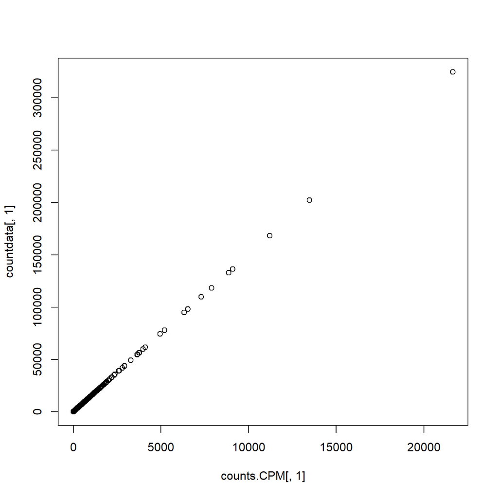

```r
> plot(counts.CPM[,1],countdata[,1])
```

## Uso de clases específicas para manejar los datos

La primera parte del pre-procesado se ha llevado a cabo sin utilizar ni funciones ni clases específicas, como podría ser expressionSet,summarizedExperimentpara los datos o alguna variante densFilter` para el filtraje.

En este estudio vamos a usar la clase `DGEList`, una clase S4, que la encontramos en el paquete `edgeR` el cual utiliza listas para almacenar recuentos de “reads”(lecturas) y la información asociada de la tecnologías usadas de secuenciación o expresión génica digital.

```r
> dgeObj <- DGEList(counts.keep)
> dgeObj
```

```
An object of class "DGEList"
$counts
                COV145 COV147 COV149 COV150 COV151 COV152 COV153 COV154 COV155
ENSG00000268903     18     10      4      8     33     10      8     13     27
ENSG00000269981     11      1      5      7     23      1      4     18     18
ENSG00000279928      4      5      7     11      0      2      4      3      1
ENSG00000279457     29     44     16     15     24     13     41     25     39
ENSG00000237094     10      4      4      1      7      4      3      5      3
                COV156 COV157 COV175 COV176 COV177 COV178 COV179 COV180 HEA061
ENSG00000268903     19      8     11      9     13     12      7     11      9
ENSG00000269981     24      5      6      9     16      6      2      3     11
ENSG00000279928      3      3      7      6      9      2      0      9      6
ENSG00000279457     20     17     23     43     55     22     19     17     54
ENSG00000237094      8      6      8      7      7      2      1      2      6
                HEA062 HEA063 HEA064 HEA065 HEA066 HEA067 HEA068 HEA069 HEA070
ENSG00000268903     18     14      4      8      9     17      6      8      6
ENSG00000269981      9      2      8      5      6     17      6      8      5
ENSG00000279928     11      1     14      0     18     18     14      5      7
ENSG00000279457     63     51     53     32     32     52     35     34     58
ENSG00000237094      4      5      6      4      7      2      1      8      0
                HEA071 HEA181 HEA182 HEA183 HEA184 HEA185 HEA186
ENSG00000268903     14      8     10      6      5      7     14
ENSG00000269981     14      6     16      4      7      1     13
ENSG00000279928      9      1      5      8      7     11      7
ENSG00000279457     44     24     15     35     62     37      7
ENSG00000237094      2      6     10      3      2      4      8
18581 more rows ...

$samples
       group lib.size norm.factors
COV145     1 15014286            1
COV147     1 13908153            1
COV149     1 13479142            1
COV150     1 18825725            1
COV151     1 13630305            1
29 more rows ...
```

```r
> names(dgeObj)
```

```
[1] "counts"  "samples"
```

```r
> dgeObj$samples
```

|  | group | lib.size | norm.factors |
| --- | --- | --- | --- |
| COV145 | 1 | 15014286 | 1 |
| COV147 | 1 | 13908153 | 1 |
| COV149 | 1 | 13479142 | 1 |
| COV150 | 1 | 18825725 | 1 |
| COV151 | 1 | 13630305 | 1 |
| COV152 | 1 | 13241647 | 1 |
| COV153 | 1 | 12943939 | 1 |
| COV154 | 1 | 14266203 | 1 |
| COV155 | 1 | 17119640 | 1 |
| COV156 | 1 | 15585442 | 1 |
| COV157 | 1 | 16977785 | 1 |
| COV175 | 1 | 13328942 | 1 |
| COV176 | 1 | 13641949 | 1 |
| COV177 | 1 | 16052715 | 1 |
| COV178 | 1 | 17325906 | 1 |
| COV179 | 1 | 13615237 | 1 |
| COV180 | 1 | 13682842 | 1 |
| HEA061 | 1 | 16969765 | 1 |
| HEA062 | 1 | 17338880 | 1 |
| HEA063 | 1 | 15552767 | 1 |
| HEA064 | 1 | 16134045 | 1 |
| HEA065 | 1 | 19399176 | 1 |
| HEA066 | 1 | 18233622 | 1 |
| HEA067 | 1 | 16375136 | 1 |
| HEA068 | 1 | 14862232 | 1 |
| HEA069 | 1 | 14918252 | 1 |
| HEA070 | 1 | 20423100 | 1 |
| HEA071 | 1 | 17802163 | 1 |
| HEA181 | 1 | 14937016 | 1 |
| HEA182 | 1 | 14254802 | 1 |
| HEA183 | 1 | 18266064 | 1 |
| HEA184 | 1 | 17125206 | 1 |
| HEA185 | 1 | 16446167 | 1 |
| HEA186 | 1 | 16814593 | 1 |

## Exploración de los datos

Una vez que ya hemos quitado los genes con poca expresion y los recuentos los alamacenamos en un objeto llamado DGEList, con el que vamos a realizar algunos gráficos exploratorios para determinar si los datos aparentan buena calidad y/o si presentan algún problema.

## Boxplot de los recuentos no normalizados

Para poder explorar y ver los datos, debemos de trabajar con versiones transformadas de los datos de recuento. Me encuentro que la distribución de los valores de recuento está muy sesgada, la transformación log2 ayuda a normalizar aproximadamente las distribuciones. Normalmente debemos de usar la base logarítmica 2, con ella puedo realizar una conversión a la escala original. Usare la función `cpm` para obtener recuentos `log2` por millón, que se corrigen para los diferentes tamaños de biblioteca. La función `cpm` también agrega una pequeña cantidad evitar tomar log de cero. Este sera el primer paso veremos como se encuentran los datos no normalizados

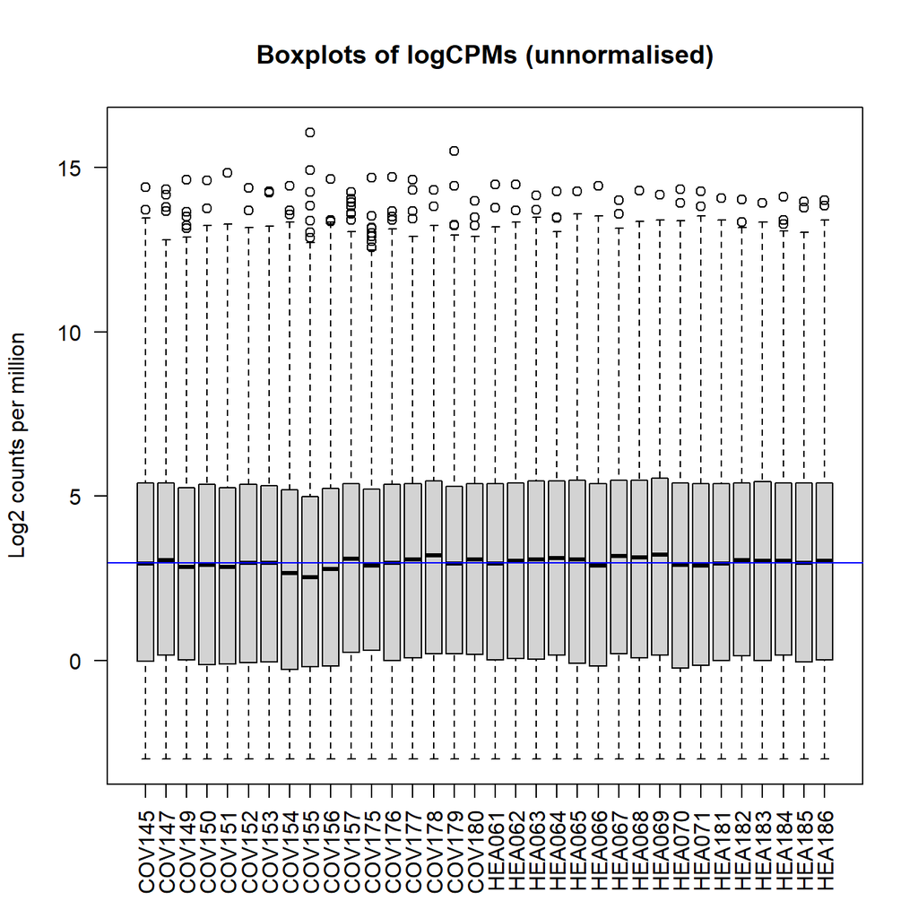

```r
> # Get log2 counts per million
> logcounts <- cpm(y,log=TRUE)
> # Check distributions of samples using boxplots
> boxplot(logcounts, xlab="", ylab="Log2 counts per million",las=2)
> # la linea azul corresponde a la media del  logCPM
> abline(h=median(logcounts),col="blue")
> title("Boxplots of logCPMs (unnormalised)")
```

## Normalización

El siguiente paso es la normalización consiste en eliminar los sesgos de composición entre librerías (Mark D. Robinson y Oshlack 2010). Esto genera un conjunto de factores de normalización, donde el producto de estos factores y los tamaños de librería definen el tamaño efectivo de la biblioteca. La función `calcNormFactors` calcula los factores de normalización entre librerías.

```r
> # Voy a usar la  normalización al objeto DGEList
> dgeObj_norm <- calcNormFactors(dgeObj)
```

Vuelvo a repetir los graficos, para ver si se corrige esa ligera desviación que habia en algunos

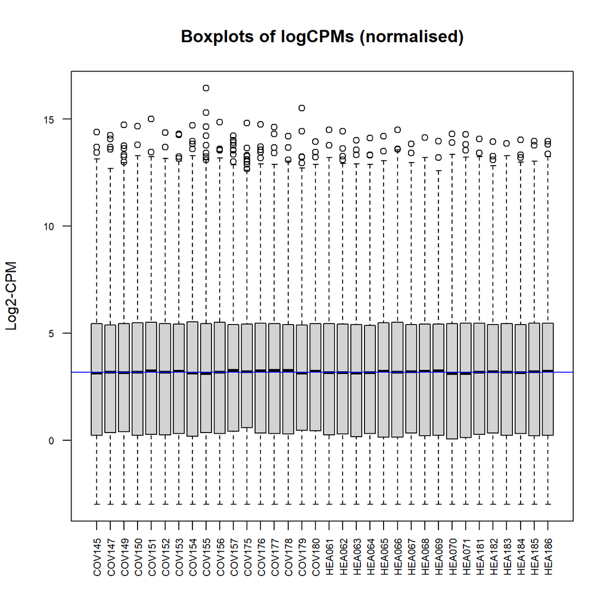

```r
> # Obtengo el log2 recuentos por millón
> logcounts_norm <- cpm(dgeObj_norm,log=TRUE)
> # Check distributions of samples using boxplots
> boxplot(logcounts_norm, ylab="Log2-CPM",las=2, xlab="", cex.axis=0.7, main="Boxplots of logCPMs (normalised)")
> # Let's add a blue horizontal line that corresponds to the median logCPM
> abline(h=median(logcounts_norm), col="blue")
```

Vale como puedo observar se ha corregido la pequeña desviación en alguna de las muestras.

## Análisis no supervisado de similaridad entre las muestras

En general, en un estudio experimental en donde buscamos comparar distintas condiciones o tratamientos, esperaremos que las muestras pertenecientes al mismo grupo se parezcan más entre ellas que a las de los otros grupos.

Esta idea intuitiva puede concretarse a través de calcular y visualizar de alguna forma la similaridad entre las muestras. Esto puede hacerse de distintas formas pero algunas de las más habituales son, el cluster o agrupamiento jerárquico y los métodos de reducción de la dimensión como el análisis de componentes principales (PCA) o el escalamiento multidimensional (MDS). Éste último tiene la ventaja que permite visualizar en dimensión reducida las similaridades entre muestras, más que los datos directos que es lo que hace el PCA. Usare el escalamiento multidimensional (MDS).

Cuando vemos nuestros datos , es importante ver si nuestras muestras difieren entre si de manera coherente al diseño del experimento, de forma que muestras similares se agrupen y se alejen de las que no son tan similares.Con esto confirmo si son similares. El análisis de las distancias Euclídeas entre muestras puede poner de manifiesto este efecto, usare la función `dist` en los datos que he transformado.

```r
> sampleDists <- dist(t(logcounts_norm))
> sampleDists
```

[output not shown]

[output cut: 115 more lines]

```
HEA063
HEA064
HEA065
HEA066
HEA067
HEA068
HEA069
HEA070
HEA071
HEA181
HEA182  92.71876
HEA183  82.06317  91.18286
HEA184  85.18255  90.97983  82.74586
HEA185  89.96913  98.07474  89.92156  90.52276
HEA186  90.87345  93.84188  88.60668  93.22536  97.29063
```

Como ya he generado los datos puedo crear mi matriz de distancias y que posteriormente puedo usar para representarlas gráficamente en un heatmap;

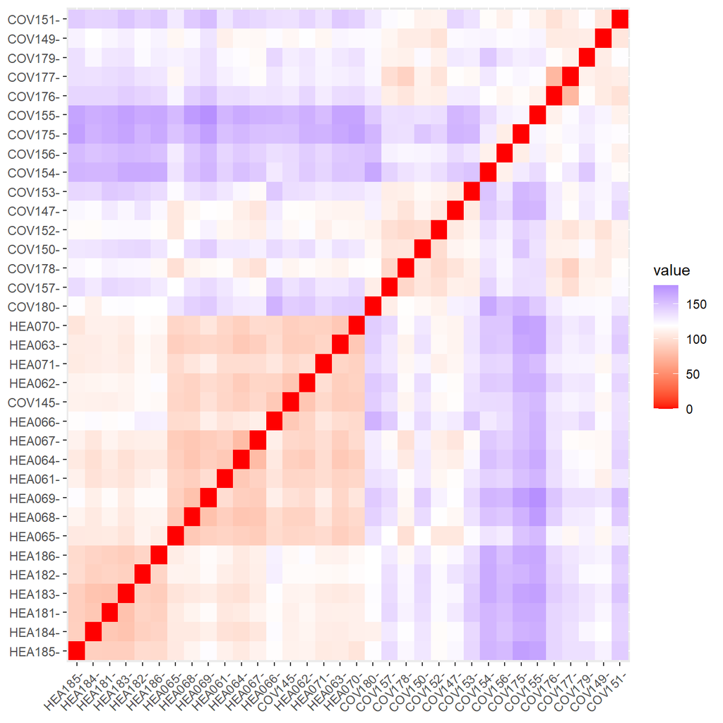

```r
> library(factoextra)
> fviz_dist(sampleDists)
```

Una vez obtenida la matriz de distancias voy a realizar un agrupamiento jerárquico.

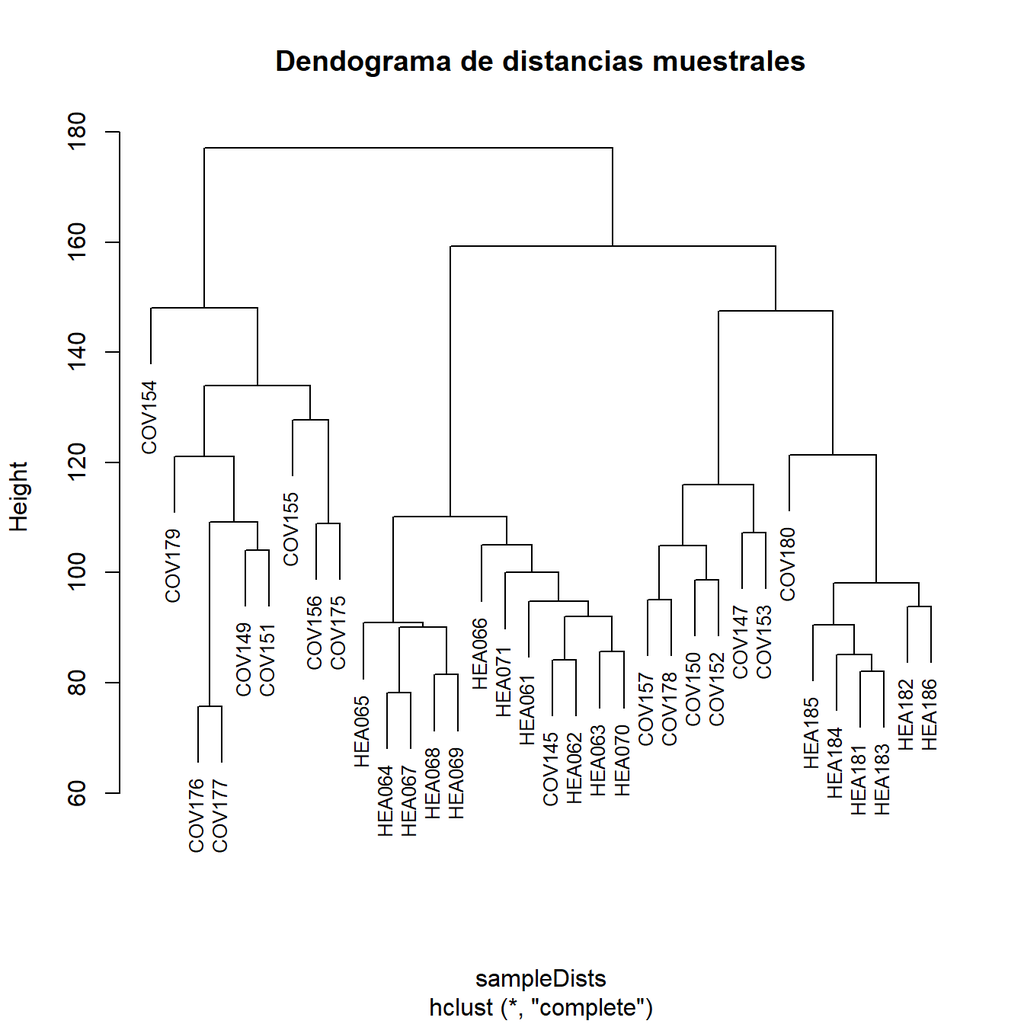

```r
> plot(hclust(sampleDists),labels = colnames(logcounts_norm),main = "Dendograma de distancias muestrales", cex=0.8)
```

El dendograma de distancias me enseña un grupo de sujetos con Covid los cuales tienes cierta similitud con los sujetos sanos, aunque si me doy cuenta tengo la muestra COVID145 dentro del dendrograma co los sanos Otra manera de comprobar esto es mediante un análisis de componentes principales.

## Visualización en dimensión reducida

Un enfoque complementario para determinar las principales fuentes de variabilidad en los datos es la visualización en dimensión reducida, ya sea de los datos o de la matriz de similaridades. Usare el escalamiento multidimensional.

De forma análoga, el escalamiento multidimensional permite llevar a cabo una transformación similar a la del PCA, pero con la matriz de distancias, lo que proporciona una representación en dimensión reducida que describe con relativa fidelidad las diferencias y similaridades entre muestras.

Para esta segunda representación utilizaremos la función plotMDS. Es un poco difícil ver exactamente qué está pasando con la gráfica predeterminada, aunque vemos muestras que se agrupan en pares.

Con el escalamiento multidimensional hare una transformación similar a la del PCA,usare la matriz de distancias, lo que proporciona una representación en dimensión reducida que describe con relativa fidelidad las diferencias y similaridades entre muestras. Para ello, utilizaremos la función `plotMDS`.

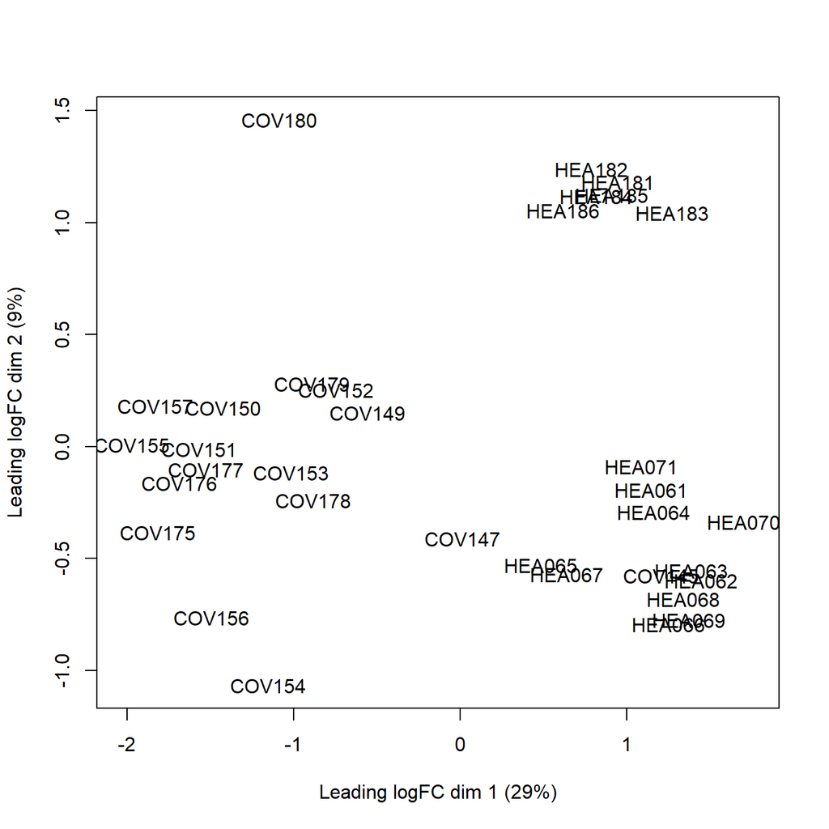

```r
> plotMDS(logcounts_norm)
```

En la gráfica me encuentro las muestras bien diferenciados excepto una muestra con Covid(COVID145),esto mismo me lo encontraba en el dendrograma esto me dice que representa cierta similitud con los sujetos sanos.

# Análisis de expresión diferencial con limma-voom

Una vez normalizados los datos, y tras comprobar su calidad, podemos proceder a seleccionar genes diferencialmente expresados.

Desde el inicio del análisis de datos de RNA-seq se ha puesto énfasis en la diferencia entre datos de microarrays, que son variables continuas que proporcionan una medida indirecta de la expresión génica, frente a los datos de RNA-seq que son contajes de secuencias por lo que miden directamente la expresión.

Siguiendo una cierta ortodoxia estadística, los primeros se suelen modelizar y analizar con (extensiones) del modelo lineal general, por ejemplo usando el paquete limma y los segundos con (extensiones) de modelos lineales generalizados propios de datos de contaje, usando por ejemplo el paquete DESEQ2 o edgeR. Recientemente se introdujo una solución intermedia para datos de contaje consistente en aplicarles una transformación que los hace continuos permitiendo analizarlos con el paquete limma o su extensión Glimma.

El paquete limma (Ritchie et al. 2015) ofrece la función voom, que transforma los recuentos de “reads” en logCMM teniendo en cuenta la relación media-varianza en los datos (Charity W. Law et al. 2014). Una vez transformados los datos (vooming), los usuarios pueden aplicar un modelo lineal a los datos transformados en voom para probar genes expresados diferencialmente, con la suposición de que los datos subyacentes se distribuyen normalmente.

La ventaja principal de esta aproximación es que permite trabajar con toda la flexibilidad de los modelos lineales para representar diseños experimentales, y, en muchos casos , aprovechar la experiencia previa del usuario en el manejo de limma.

Como ya tengo normalizados los datos, y he podido comprobar su calidad, voy a seleccionar genes diferencialmente expresados.

El paquete `limma` ofrece la función `voom`, que transforma los recuentos de “reads” en `logCMM` teniendo en cuenta la relación media-varianza en los datos. Una vez tengo ya transformados los datos (`vooming`), puedo aplicar un modelo lineal a los datos transformados en voom para probar genes expresados diferencialmente, con la suposición de que los datos subyacentes se distribuyen normalmente.

## Creación de la matriz de diseño y de contrastes

```r
> # Especificar una matriz de diseño sin un término de intersección
> group<-paste(sampleinfo$group, sep = ".")
> design <- model.matrix(~ 0 + group)
> colnames(design)<-gsub("group","",colnames(design))
> rownames(design)<-sampleinfo$group
> design
```

|  | COVID | HEALTH |
| --- | --- | --- |
| COVID | 1 | 0 |
| COVID | 1 | 0 |
| COVID | 1 | 0 |
| COVID | 1 | 0 |
| COVID | 1 | 0 |
| COVID | 1 | 0 |
| COVID | 1 | 0 |
| COVID | 1 | 0 |
| COVID | 1 | 0 |
| COVID | 1 | 0 |
| COVID | 1 | 0 |
| COVID | 1 | 0 |
| COVID | 1 | 0 |
| COVID | 1 | 0 |
| COVID | 1 | 0 |
| COVID | 1 | 0 |
| COVID | 1 | 0 |
| HEALTH | 0 | 1 |
| HEALTH | 0 | 1 |
| HEALTH | 0 | 1 |
| HEALTH | 0 | 1 |
| HEALTH | 0 | 1 |
| HEALTH | 0 | 1 |
| HEALTH | 0 | 1 |
| HEALTH | 0 | 1 |
| HEALTH | 0 | 1 |
| HEALTH | 0 | 1 |
| HEALTH | 0 | 1 |
| HEALTH | 0 | 1 |
| HEALTH | 0 | 1 |
| HEALTH | 0 | 1 |
| HEALTH | 0 | 1 |
| HEALTH | 0 | 1 |
| HEALTH | 0 | 1 |

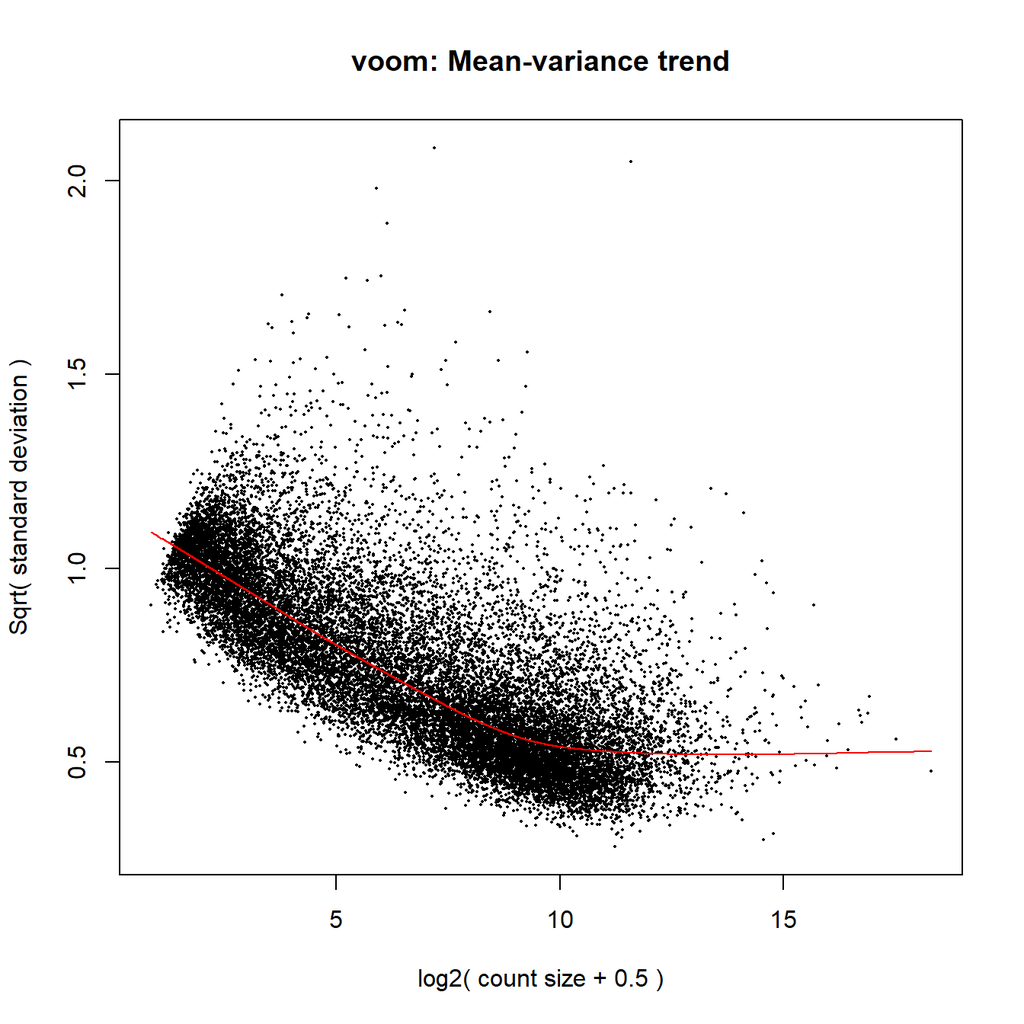

```r
> par(mfrow=c(1,1))
> v <- voom(y,design,plot = TRUE)
```

Dado que estamos interesados en las diferencias entre los grupos, necesitamos especificar qué comparaciones queremos llevar a cabo. Las comparaciones de interés se puede especificar utilizando la función makeContrasts. La matriz de contraste indica qué columnas de la matriz design vamos a comparar.

```r
> cont.matrix <- makeContrasts(COVIDvsHEALTH=COVID-HEALTH, levels=design)
> cont.matrix
```

|  | COVIDvsHEALTH |
| --- | --- |
| COVID | 1 |
| HEALTH | -1 |

## Transformación de los datos

Como he comentado la funcion voom creará un nuevo objeto con campos equivalentes a los del `DGELIST` pero que puede ser analizado con limma.

```r
> voomObj <- voom(dgeObj_norm, design)
> voomObj
```

```
An object of class "EList"
$targets
       group lib.size norm.factors
COV145     1 15236135    1.0147759
COV147     1 14838216    1.0668718
COV149     1 12532450    0.9297662
COV150     1 18188551    0.9661541
COV151     1 12054638    0.8843997
29 more rows ...

$E
                    COV145     COV147     COV149     COV150     COV151
ENSG00000268903  0.2800282 -0.4989284 -1.4776717 -1.0974960  1.4745727
ENSG00000269981 -0.4058632 -3.3062833 -1.1881651 -1.2780682  0.9630723
ENSG00000279928 -1.7595002 -1.4318142 -0.7407061 -0.6613968 -4.5915165
ENSG00000279457  0.9532179  1.5844876  0.3967974 -0.2307625  1.0231933
ENSG00000237094 -0.5371078 -1.7213208 -1.4776717 -3.5999963 -0.6846259
                     COV152     COV153     COV154    COV155     COV156
ENSG00000268903 -0.33794693 -0.5659529  0.1894709  1.072443  0.5280201
ENSG00000269981 -3.14530185 -1.4834907  0.6440368  0.500537  0.8573277
ENSG00000279928 -2.40833626 -1.4834907 -1.7580616 -3.123954 -1.9500272
ENSG00000279457  0.02462315  1.7216237  1.1070088  1.594864  0.6001699
ENSG00000237094 -1.56033935 -1.8460608 -1.1059850 -1.901561 -0.6699193
                      COV157     COV175     COV176      COV177     COV178
ENSG00000268903 -1.032006510 -0.0903481 -0.4722081 -0.25606487 -0.6020525
ENSG00000269981 -1.660037733 -0.9134703 -0.4722081  0.03344175 -1.5454690
ENSG00000279928 -2.312114429 -0.7070195 -1.0196959 -0.76302486 -2.9239806
ENSG00000279457  0.009813666  0.9406788  1.7228079  1.78346349  0.2459444
ENSG00000237094 -1.419029633 -0.5264472 -0.8132450 -1.10406178 -2.9239806
                    COV179     COV180     HEA061      HEA062     HEA063
ENSG00000268903 -0.8549780 -0.2685581 -0.8391945  0.03112325 -0.2395097
ENSG00000269981 -2.4399405 -1.9847652 -0.5635601 -0.93040260 -2.7755626
ENSG00000279928 -4.7618685 -0.5441926 -1.3866823 -0.65476815 -3.5125282
ENSG00000279457  0.5235337  0.3371629  1.6810623  1.81035458  1.5890098
ENSG00000237094 -3.1769060 -2.4701920 -1.3866823 -2.00840511 -1.6380591
                    HEA064     HEA065      HEA066       HEA067     HEA068
ENSG00000268903 -2.0011754 -1.2633718 -0.87608376 -0.075727376 -1.3415779
ENSG00000269981 -1.0836375 -1.8914030 -1.42357156 -0.075727376 -1.3415779
ENSG00000279928 -0.3131194 -5.3508347  0.08544209  0.004442973 -0.1840366
ENSG00000279457  1.5703666  0.6715331  0.89835654  1.509235125  1.1077295
```

[output cut: 41 more lines]

```
[1,] 1.231097 1.2431362 1.4029787 1.3569640 1.2988981 1.326499
[2,] 1.091973 1.1024080 1.2406707 1.2009353 1.1507100 1.174586
[3,] 1.034976 1.0447714 1.1743970 1.1371604 1.0900787 1.112471
[4,] 2.517731 2.5431921 2.8804920 2.7837798 2.6613060 2.719442
[5,] 0.834936 0.8425384 0.9427816 0.9140301 0.8776351 0.894969
18581 more rows ...

$design
      COVID HEALTH
COVID     1      0
COVID     1      0
COVID     1      0
COVID     1      0
COVID     1      0
29 more rows ...
```

## Selección de genes diferencialmente expresados

La seleccion de genes la use en la primera PEC, que fue sobre microarrays el objeto voomObj y las matrices de diseño y contrastes la utilizo para ajustar un modelo y, a continuación realizar las comparaciones especificadas en el modelo ajustado. El proceso finaliza con la regularización del estimador del error usando la función eBayes.

```r
> # Fit del modelo lineal
> fit <- lmFit(voomObj)
> fit.cont <- contrasts.fit(fit, cont.matrix)
> fit.cont <- eBayes(fit.cont)
```

## Top tables

Los resultados de un análisis de expresión diferencial se pueden extraer con la función topTable. Esta función genera una tabla de resultados cuyas columnas contienen información acerca de los genes y la diferencia entre los grupos comparados. Concretamente:

-logFCcolumn da el cambio en escala logarítmica en la expresión de un gen entre los grupos comparados.

-AveExpr da el nivel promedio de expresión log2 para ese gen en todas las muestras del experimento.

-t es el valor del estadístico “t-moderada”, similar al estadístico del test “t” de student, pero con un estimador mejorado de la varianza en su denominador.

-P.Value es el valor p asociado a la comparación realizada.

-Adj. P.Value es el valor p ajustado para comparaciones múltiples . La forma más popular de ajuste es “BH”, que es el método de Benjamini y Hochberg para controlar la tasa de falsos positivos (FDR).

-B es el logaritmo de la probabilidad posterior de que el gen se exprese diferencialmente frente a que no lo haga. Básicamente, cuanto mayor es B, más plausible resulta que el gen se encuentre diferencialmente expresado.

```r
> toptab_CvsH <- topTable(fit.cont,coef=1,sort.by="p", number=nrow(fit.cont))
> head(toptab_CvsH)
```

|  | logFC | AveExpr | t | P.Value | adj.P.Val | B |
| --- | --- | --- | --- | --- | --- | --- |
| ENSG00000167900 | 2.989593 | 4.050618 | 11.45970 | 0 | 0 | 20.91897 |
| ENSG00000187837 | 1.740576 | 4.418058 | 11.34649 | 0 | 0 | 20.63717 |
| ENSG00000211896 | 5.239619 | 9.401382 | 11.17700 | 0 | 0 | 20.17787 |
| ENSG00000135476 | 2.792749 | 1.356747 | 10.74110 | 0 | 0 | 18.85567 |
| ENSG00000171848 | 3.553050 | 4.592503 | 10.53293 | 0 | 0 | 18.59103 |
| ENSG00000111206 | 2.861125 | 1.750115 | 10.43533 | 0 | 0 | 18.19034 |

Para poder ver los resultados de nuestra comparación uso un `volcanoPlot`:

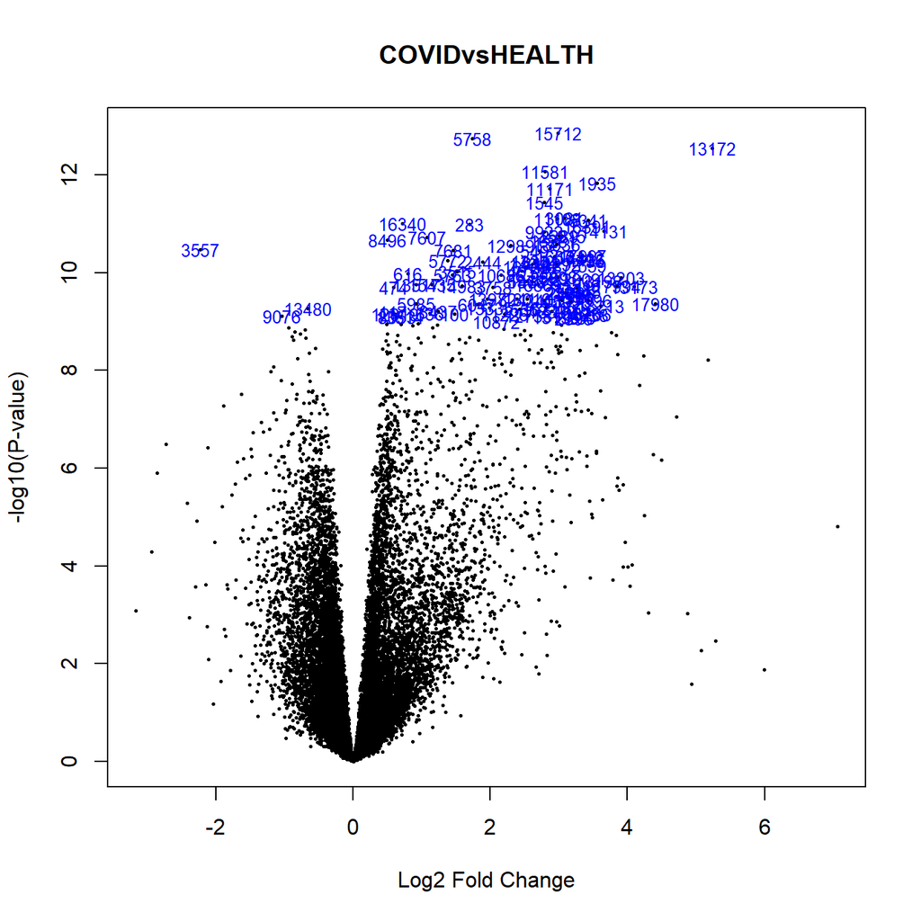

```r
> volcanoplot(fit.cont,coef=1,highlight=100,names=fit.cont$genes$SYMBOL, main="COVIDvsHEALTH")
```

el resultado lo puedo guardar en un archivos de texto o enviarse a tablas HTML interactivas..

```r
> write.csv(toptab_CvsH, "toptab_CvsH.csv")
```

## Comparaciones múltiples y visualización de los resultados

Cuando se llevan a cabo varias comparaciones es interesante compararlas entre ellas para saber cuantos genes diferencialmente expresados (GDE) se han seleccionado en cada una. La función de limma decideTests generar un resumen rápido de dichos genes a partir del umbral definido por un p-valor ajustado (retendrá los valores cuyo p-valor sea inferior al punto de corte) y un “log-Fold-Change” (retendrá los valores cuyo log-fold-change sea superior al punto de corte) proporcionados por el usuario.

```r
> summa_fit <- decideTests(fit.cont, p.value = 0.05, lfc = 2)
> summary(summa_fit)
```

|  | COVIDvsHEALTH |
| --- | --- |
| Down | 14 |
| NotSig | 18278 |
| Up | 294 |

Un diagrama de Venn, pero como solo tengo un grupo para comparar solo sale un grafico con los genes que se queda.

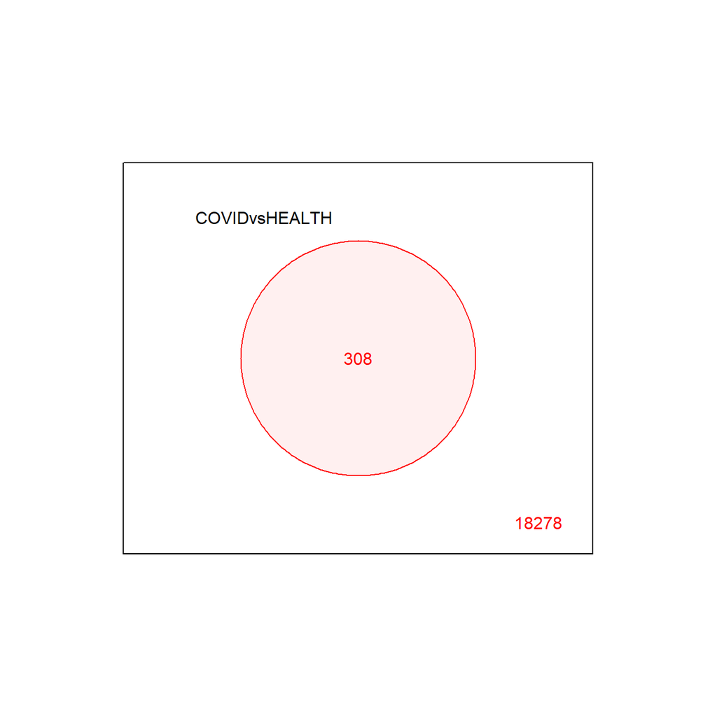

```r
> vc<- vennCounts(summa_fit)
> vennDiagram(vc, include=c("up", "down"),
+     counts.col=c("red", "blue"),
+     circle.col = c("red", "blue", "green3"), cex=c(1,1,1))
```

## Visualización de perfiles de expresión

Los perfiles de expresión obtenidos para los genes expresados diferencialmente superiores se pueden trazar en un mapa de calor, con genes (filas) y muestras (columnas) agrupados por similitud.

```r
> library(pheatmap)
> topGenes <- rownames(subset(toptab_CvsH, (abs(logFC)> 2) & (adj.P.Val < 0.05)))
> length(topGenes)
```

```
[1] 308
```

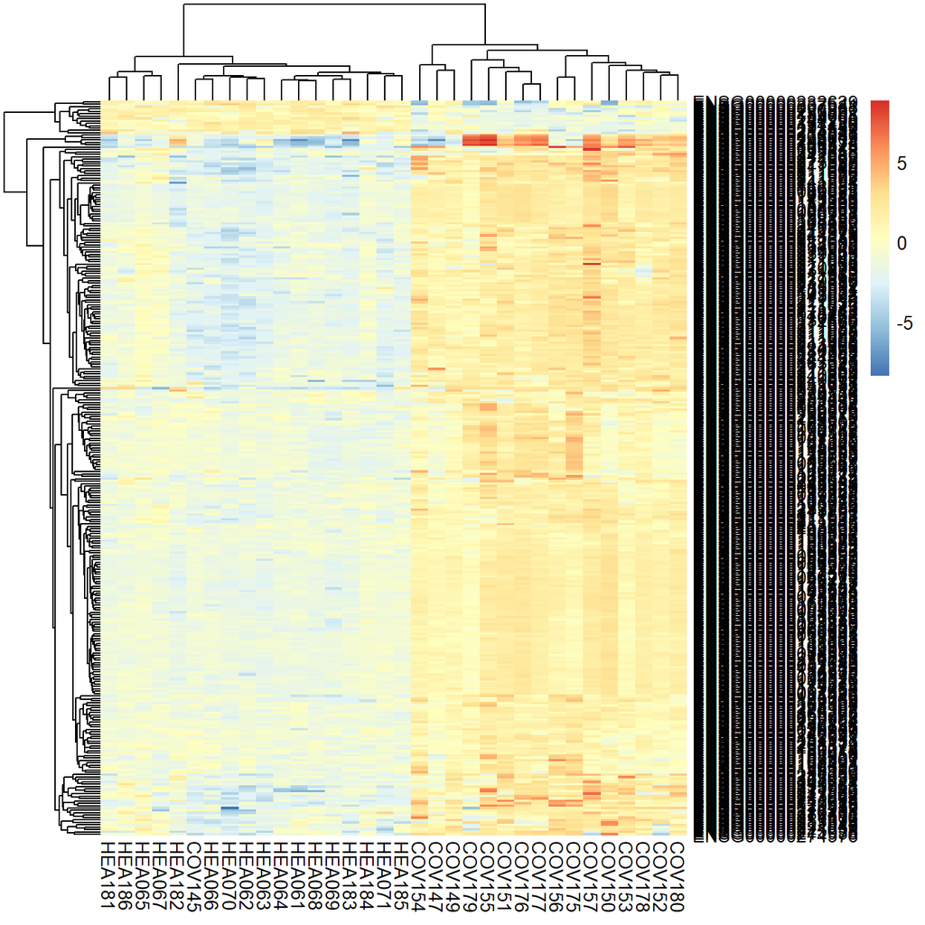

```r
> mat  <- logcounts_norm[topGenes, sampleinfo$SampleName]
> mat  <- mat - rowMeans(mat)
> library(pheatmap)
> pheatmap(mat)
```

Aqui teng mi mapa de calor junto con los cluster.

# Análisis de significación biológica

Una vez seleccionados los genes diferencialmente expresados podemos proceder al análisis de las listas de genes obtenidas.

Cambiamos de nombre la tabla resultante del análisis con lo que resultaría más sencillo adaptar los análisis para otras tablas.

```r
> topTab<- toptab_CvsH
> head(topTab)
```

|  | logFC | AveExpr | t | P.Value | adj.P.Val | B |
| --- | --- | --- | --- | --- | --- | --- |
| ENSG00000167900 | 2.989593 | 4.050618 | 11.45970 | 0 | 0 | 20.91897 |
| ENSG00000187837 | 1.740576 | 4.418058 | 11.34649 | 0 | 0 | 20.63717 |
| ENSG00000211896 | 5.239619 | 9.401382 | 11.17700 | 0 | 0 | 20.17787 |
| ENSG00000135476 | 2.792749 | 1.356747 | 10.74110 | 0 | 0 | 18.85567 |
| ENSG00000171848 | 3.553050 | 4.592503 | 10.53293 | 0 | 0 | 18.59103 |
| ENSG00000111206 | 2.861125 | 1.750115 | 10.43533 | 0 | 0 | 18.19034 |

```r
> allEntrezs <- rownames(topTab)
> selectedEntrezsUP <- rownames(subset(topTab, (logFC> 2) & (adj.P.Val < 0.05)))
> length(allEntrezs);
```

```
[1] 18586
```

```r
> length(selectedEntrezsUP)
```

```
[1] 294
```

-la lista de genes analizados y -la lista de genes seleccionados.

Nos centraremos únicamente en la lista de genes “up-regulados” es decir diferencialmente expresados con un logFC mayor que dos (más expresados en “COVID” que en “HEALTH”).

Para el análisis de enriquecimiento utilizaremos la función enrichGO del paquete clusterProfiler muy parecida a las de otros paquetes como GOstats`

```r
> library(clusterProfiler)
> ego <- enrichGO(gene = selectedEntrezsUP,
+                 universe = allEntrezs,
+                 keyType = "ENSEMBL",
+                 OrgDb = org.Hs.eg.db,
+                 ont = "BP",
+                 pAdjustMethod = "BH",
+                 qvalueCutoff = 0.05,
+                 readable = TRUE)
>
> #El objeto resultante almacena las categorías GO enriquecidas, los genes anotados en ellas y los valores de los estadísticos que llevan a afirmar que dichas categorías se encuentran significativamente sobre-representadas como resultado de un test de enriquecimiento.
>
> head(ego)
```

|  | ID | Description | GeneRatio | BgRatio | pvalue | p.adjust | qvalue | geneID | Count |
| --- | --- | --- | --- | --- | --- | --- | --- | --- | --- |
| GO:0006958 | GO:0006958 | complement activation, classical pathway | 47/258 | 72/12701 | 0 | 0 | 0 | IGHG1/IGKC/IGLC3/IGHV4-34/IGHV1-18/IGHG3/IGLC2/IGHV4-59/IGHV3-23/IGHV5-51/IGHV3-21/IGHV1-24/IGHA1/IGHV3-33/IGHV3-11/IGHV3-49/CLU/IGHV3-30/C1QB/IGHV3-48/IGHV3-7/IGHV3-20/IGHA2/IGHV4-61/C1QC/IGHV3-66/IG… | 47 |
| GO:0002455 | GO:0002455 | humoral immune response mediated by circulating immunoglobulin | 48/258 | 84/12701 | 0 | 0 | 0 | IGHG1/IGKC/IGLC3/IGHV4-34/IGHV1-18/IGHG3/IGLC2/IGHV4-59/IGHV3-23/IGHV5-51/EXO1/IGHV3-21/IGHV1-24/IGHA1/IGHV3-33/IGHV3-11/IGHV3-49/CLU/IGHV3-30/C1QB/IGHV3-48/IGHV3-7/IGHV3-20/IGHA2/IGHV4-61/C1QC/IGHV3-… | 48 |
| GO:0006910 | GO:0006910 | phagocytosis, recognition | 44/258 | 66/12701 | 0 | 0 | 0 | IGHG1/IGKC/IGLC3/IGHV4-34/IGHV1-18/IGHG3/IGLC2/IGHV4-59/IGHV3-23/IGHV5-51/IGHV3-21/IGHV1-24/IGHA1/IGHV3-33/IGHV3-11/IGHV3-49/IGHV3-30/IGHV3-48/IGHV3-7/IGHV3-20/IGHA2/IGHV4-61/IGHV3-66/IGHV3-43/IGHV3-1… | 44 |
| GO:0006956 | GO:0006956 | complement activation | 47/258 | 84/12701 | 0 | 0 | 0 | IGHG1/IGKC/IGLC3/IGHV4-34/IGHV1-18/IGHG3/IGLC2/IGHV4-59/IGHV3-23/IGHV5-51/IGHV3-21/IGHV1-24/IGHA1/IGHV3-33/IGHV3-11/IGHV3-49/CLU/IGHV3-30/C1QB/IGHV3-48/IGHV3-7/IGHV3-20/IGHA2/IGHV4-61/C1QC/IGHV3-66/IG… | 47 |
| GO:0006911 | GO:0006911 | phagocytosis, engulfment | 44/258 | 99/12701 | 0 | 0 | 0 | IGHG1/IGKC/IGLC3/IGHV4-34/IGHV1-18/IGHG3/IGLC2/IGHV4-59/IGHV3-23/IGHV5-51/IGHV3-21/IGHV1-24/IGHA1/IGHV3-33/IGHV3-11/IGHV3-49/IGHV3-30/IGHV3-48/IGHV3-7/IGHV3-20/IGHA2/IGHV4-61/IGHV3-66/IGHV3-43/IGHV3-1… | 44 |
| GO:0006959 | GO:0006959 | humoral immune response | 54/258 | 182/12701 | 0 | 0 | 0 | IGHG1/IGKC/IGLC3/JCHAIN/IGHV4-34/IGHV1-18/IGHG3/IGLC2/IGHV4-59/IGHV3-23/IGHV5-51/EXO1/IGHV3-21/H2BC7/IGHV1-24/IGHA1/IGKV3-20/IGHV3-33/IGHV3-11/IGHV3-49/CLU/IGHV3-30/C1QB/IGHV3-48/IGHV3-7/IGHV3-20/IGHA… | 54 |

```r
> ego_results <- data.frame(ego)
> write.csv(ego_results, "clusterProfiler_ORAresults_UpGO.csv")
```

## Visualización de los resultados del análisis de enriquecimiento

Uno de los aspectos interesantes del paquete clusterProfiler es que permite visualizar los resultados mediante algunos gráficos creados específicamente para tal fin.

Este gráfico compara visualmente las categorías enriquecidas (de más a menos enriquecidas) visualizando simultáneamente cuan enriquecidas estan y el p-valor del test de enriquecimiento.

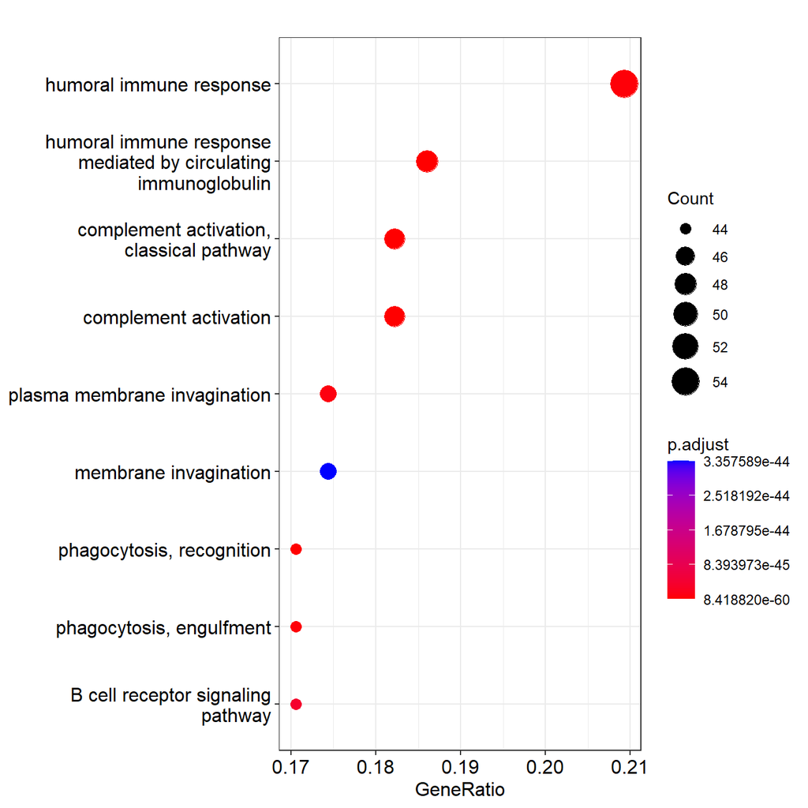

```r
> dotplot(ego, showCategory=9)
```

### Visualización jerárquica de los términos GO

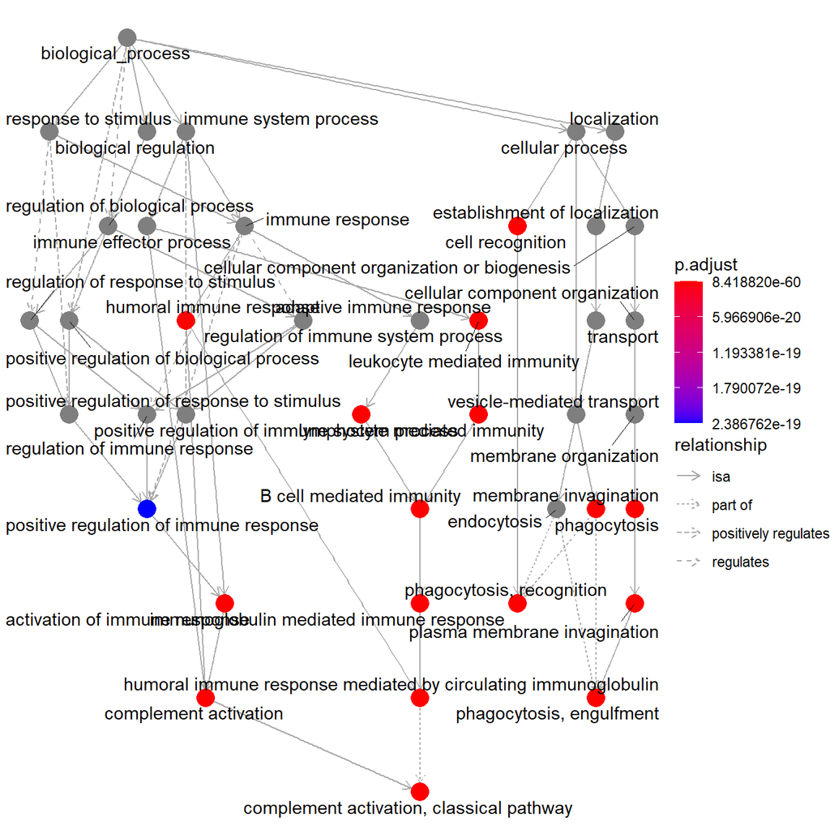

```r
> goplot(ego, showCategory=5, cex=0.5)
```

### Gene network para los términos seleccionados

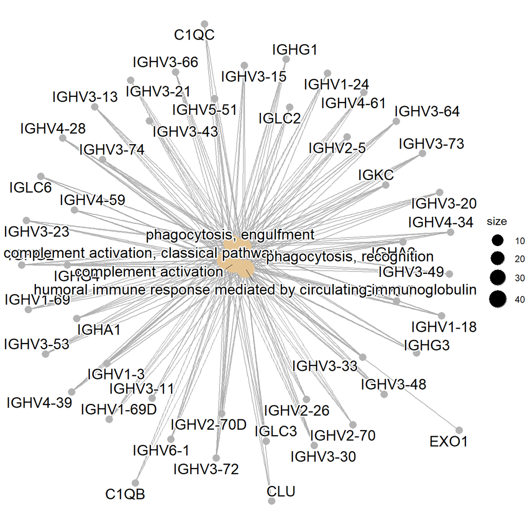

```r
> cnetplot(ego)
```

### Enrichment Map

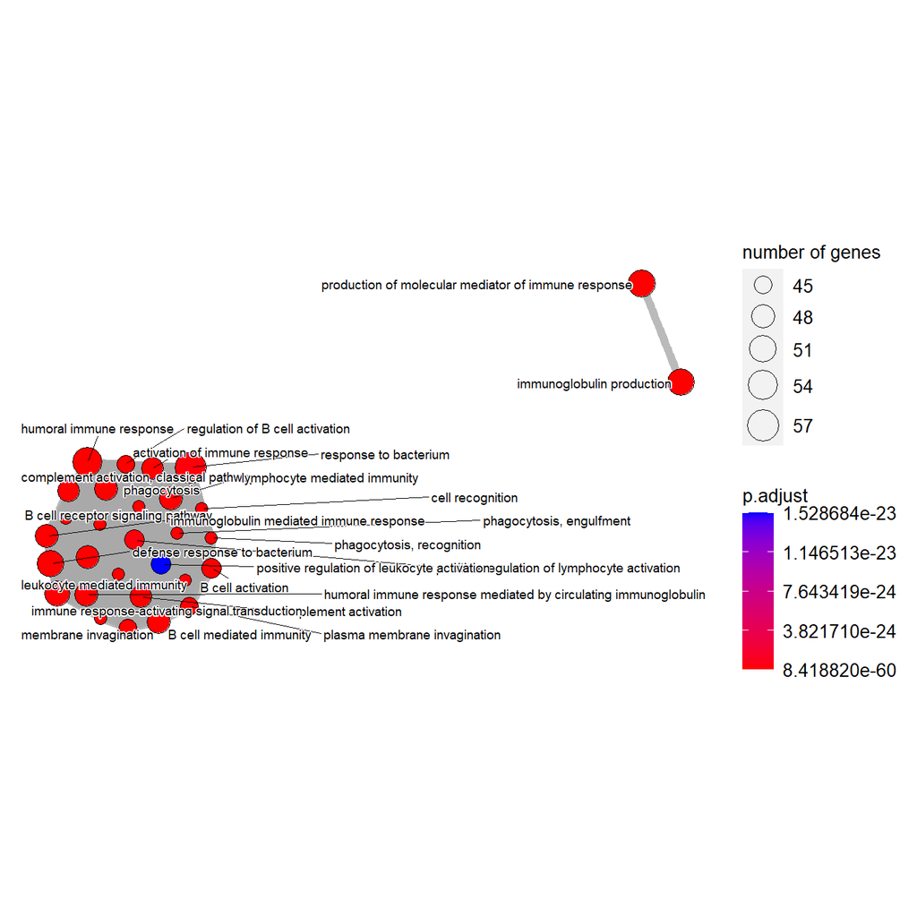

```r
> library(enrichplot)
> ego_sim <- pairwise_termsim(ego)
> emapplot(ego_sim, cex_label_category=0.5)
```

## Teoria del paquete GOSeq

**Volviendo a la idea del debate Investigue el uso del paquete GOSeq y compare con algún otro que vayáis a utilizar, ya ocean GOstats o clusterProfiler.*** Voy a explicar la teoría del paquete GOSeq

## DISCUCIÓN

El nivel de obtención de genes diferenciados significativamente puede ocasiones que sea mál complicada la identificación de término en la ontología génica (GO). Un ejemplo claro se tiene en el presente estudio en la comparativa COVID vs HEALTH, donde se siguieron las condiciones de análisis (pvalor < 0.05)

Por último, cabe menciona la importancia del conocimiento biológico para el análisis. Un buen conocimiento biológico del área de estudio, en este caso el virus COVI-19 es necesario para evitar la interpretación de resultados anómalos que nada tienen que ver con la realidad biológico.

## CONCLUSIÓN

El análisis exploratorio de los datos permite realizar una primera visualización del conjunto de los datos objeto de análisis. Tras realizar diversas gráficas (heatmap y MDS) se llega a la conclusión de que, a partir de los datos,me encuentro que los datos son absolutamente similares antes de realizar la normalizacion que despues, esto me indica que los datos son bastante parecidos

A partir del análisis de expresión diferencial se pueden obtener una serie de conclusiones interesantes. El número de genes signficativos (pvalor 0.05) obtenidos en el análisis global y en la comparativa entre COVID y hEALTH es BAJO, 308 genes.

El análisis de significancia biológico nos permite obtener una serie de conclusiones primarias, ya que es previo un mayor conocimiento biológico.

## Bibliografia

-[Radzikowska, U, stribution of ACE2, CD147, CD26, and other SARS‐CoV‐2 associated molecules in tissues and immune cells in health and in asthma, COPD, obesity, hypertension, and COVID‐19 risk factors](https://pubmed.ncbi.nlm.nih.gov/32496587/)

-[Hosseini, E.The novel coronavirus Disease-2019 (COVID-19): Mechanism of action, detection and recent therapeutic strategies](https://pubmed.ncbi.nlm.nih.gov/33010669/)

-[Rodríguez-Martín, B, ChimPipe: accurate detection of fusion genes and transcription-induced chimeras from RNA-seq data](https://pubmed.ncbi.nlm.nih.gov/28049418/)

-[Agirre, X., Castellano, G., Pascual, M., Heath, S., Kulis, M., Segura, V., … & Martín-Subero, J. I. (2015). Whole-epigenome analysis in multiple myeloma reveals DNA hypermethylation of B cell-specific enhancers.](https://pubmed.ncbi.nlm.nih.gov/25644835/)